# Estudios de Informática, Multimedia y Telecomunicaciones

# TFM-Density algorithms applied to 2dFGRS

Carlos Toro Peñas

2025-12-15

# 1 The clustering problem on galaxy dataset

Rather than pursuing a traditional unsupervised clustering optimization—such as variance maximization via the **Elbow Method**—this work evaluates the efficacy of **density-based clustering algorithms** in replicating a physically motivated **halo-based group finder**.

We aim to identify the optimal hyperparameter configurations that allow these algorithms to recover the underlying **dark matter halo membership** of galaxies, effectively using the halo-based catalog as a benchmark for physical validity.

# 2 Loading data files

## 2.1 Galaxy catalog for 2dFGRS

```
## 'data.frame':    104912 obs. of  9 variables:
##  $ GAL_ID  : int  2 3 5 6 7 8 11 12 13 14 ...
##  $ ra      : num  3.63 3.59 3.61 3.61 3.61 ...
##  $ dec     : num  -33 -32.4 -32.7 -32.9 -33 ...
##  $ x       : num  0.1 0.0854 0.0849 0.1063 0.0896 ...
##  $ y       : num  0.00634 0.00535 0.00535 0.00671 0.00566 ...
##  $ z       : num  -0.065 -0.0543 -0.0547 -0.0688 -0.0584 ...
##  $ redshift: num  0.123 0.104 0.104 0.131 0.11 ...
##  $ dist    : num  0.119 0.101 0.101 0.127 0.107 ...
##  $ GROUP_ID: int  12097 542 4846 4847 1462 1462 542 4846 4847 1462 ...
```

# 3 Generic functions for assessments

## 3.1 Functions to asses outcomes

To assess the outcomes we will based our analysis on tree basic concepts:

**Purity(P)**: measure of output-cluster: proportion of members coming exclusively from a single true group, providing confidence that the algorithm correctly groups members together. A high purity rate indicates the algorithm’s effectiveness in identifying true groups.

**Completeness (C)**: measure of an output-cluster: proportion of data true-group elements included in an output-cluster. A cluster is “complete” if contains all points of the original true group.

**Recovery (R)**: measure of an output-cluster (much more restrictive): proportion of output-clusters which are both pure and complete. For this study we consider an output-cluster to be pure if P>=0.66 (at least 2/3 of elements of an output-cluster belong to a single group). An original cluster is complete if C>=0.5 (at least half data belong to an original true group).

Some other stats are:

**total_in_group:** number of elements in a given group.

**total_in_cluster:** number of elements in a given output-cluster.

**total_in_cluster_group:** number of elements in a given output-cluster belonging to a majority-group.

**undetected_groups**: original groups not detected as majority-group in output-clusters.

**detected_groups**: original groups detected as majority-group in output-clusters.

Following code is aimed to asses the outcomes obtained with from an given output-cluster:

```r
sys.source(sprintf("%s\\assess.r", includes_folder), envir = knitr::knit_global())
```

Following code is intended to calculate stats

```r
sys.source(sprintf("%s\\calculate_stats.r", includes_folder), envir = knitr::knit_global())
```

We generated some functions to help us visualize the results graphically:

```r
sys.source(sprintf("%s\\plotting_functions.r", includes_folder),  envir = knitr::knit_global())
```

Last file to include content function to compute slos distance:

```r
sys.source(sprintf("%s\\slos.r", includes_folder),  envir = knitr::knit_global())
```

# 4 Data Preprocessing

## 4.1 Descriptive analysis **and visualization**

There is an initial pre-processing of data-file in order to obtain proper distances and Cartesian coordinates x,y,z, by now it is omitted here.

Take a sample bounded by minPts = 5 and in RA and DEC:

$$RA \in [0, 2]h,\, DEC \in [-36, -25]º,\,
\,and\,\, z \lt max\_redshift$$

Then we take the initial values and take a look at the remaining distribution:

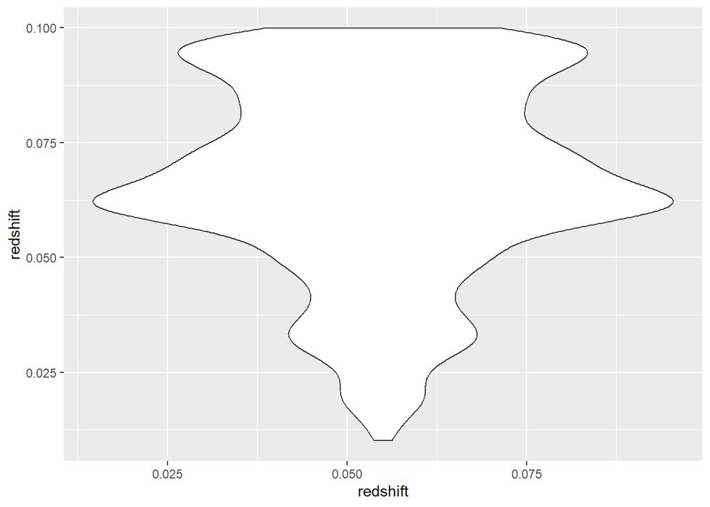

```r
SLOS <- 0 #Here the slos is not fixed beforehand
min_members <- 5
max_redshift <- 0.1
min_redshift <- 0.0
ra_lim_inf <-  0
ra_lim_sup <- 30
dec_lim_inf <- -36
dec_lim_sup <-  -25

# Take a sample using boundaries
mm <- dt[ dt$ra<= ra_lim_sup & dt$ra>=ra_lim_inf &
            dt$dec>= dec_lim_inf & dt$dec<=dec_lim_sup &
            dt$redshift< max_redshift & dt$redshift> min_redshift,]


# mm is an object containing both groups and galaxy identification
ggplot(mm, aes(x=redshift, y=redshift))+geom_violin()
```

```r
dim(mm)
```

```
## [1] 6173    9
```

Select groups with more than min_members members queries:

```r
original_mm <- mm
h<-sqldf("select
            count(GAL_ID) as members,
            GROUP_ID
          from
            mm
          group by
            GROUP_ID
          order by
            members desc")
mm5<-sqldf(sprintf("
    SELECT
        mm.GAL_ID,
        mm.x,
        mm.y,
        mm.z,
        mm.GROUP_ID,
        mm.redshift,
        mm.dist
      FROM
        mm as mm, h
      where
          mm.GROUP_ID=h.GROUP_ID and
          h.members >= %s"
      , min_members))
```

Then use it to find the target data:

```r
true_groups <- length(unique(mm5$GROUP_ID))
number_non_isolated_galaxies <- dim(mm5)[1]
number_isolated_galaxies <- dim(mm)[1] - dim(mm5)[1]
print(sprintf('Number of galaxies in groups with
              more than %s elements %s out of %s, aprox %s percent',
          min_members,
          number_non_isolated_galaxies,
          dim(mm)[1], format(number_non_isolated_galaxies * 100
                                /dim(mm)[1], digits=4)))
```

```
## [1] "Number of galaxies in groups with \n              more than 5 elements 857 out of 6173, aprox 13.88 percent"
```

```r
print(sprintf("Number of groups with more than %s members: %s",
              min_members,
              true_groups))
```

```
## [1] "Number of groups with more than 5 members: 92"
```

Do not work:

```r
tt<-sqldf(c("
       UPDATE mm
      set group_id=0
       WHERE group_id NOT IN (select distinct(group_id) from mm5)
       ", "select * from main.mm"))
mm <- tt
```

We take a look at the groups with more than min_members:

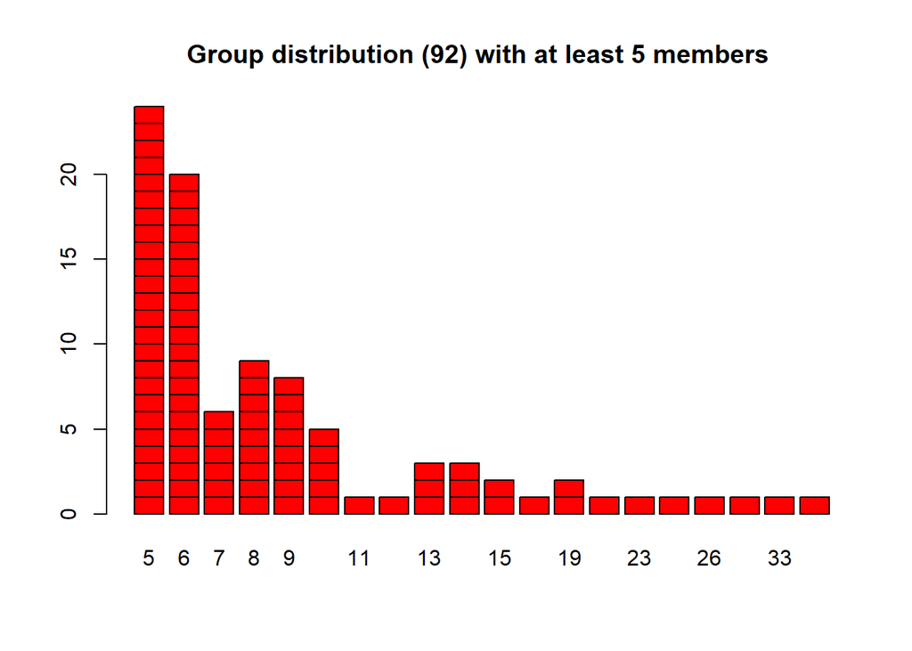

```r
hhh<- h[h$members>=min_members, ]
ttable <- table(hhh$GROUP_ID, hhh$members)
barplot(ttable, col=('red'),
        main=sprintf("Group distribution (%s) with at least %s members ",
                     true_groups,
                     min_members))
```

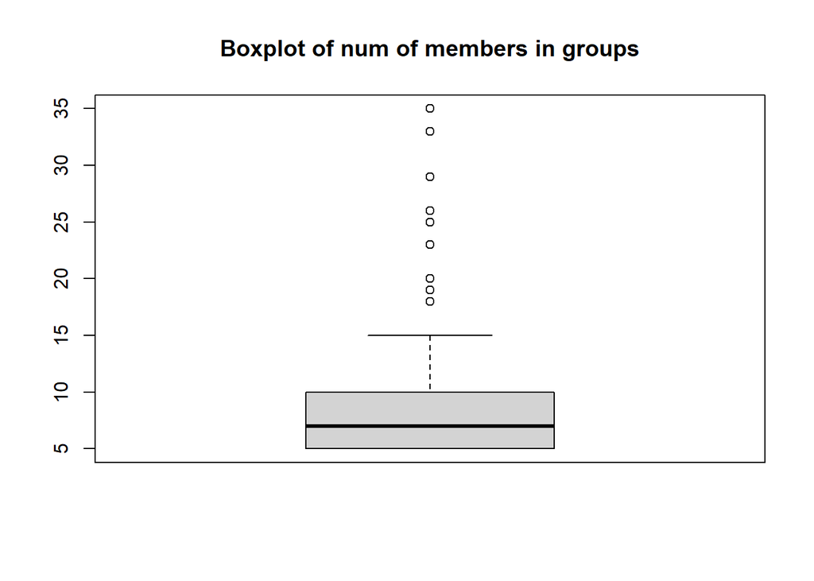

```r
boxplot(hhh$members, main="Boxplot of num of members in groups")
```

Lets take a look at the complete target sample:

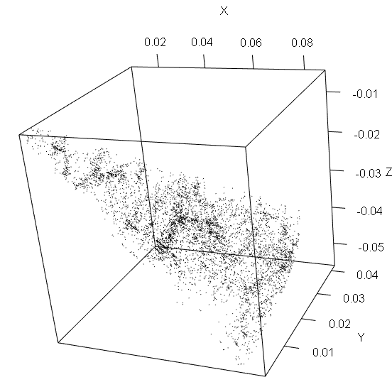

```r
plot3d(mm$x, mm$y, mm$z, col = 'black',
       size = 1, xlab = "X", ylab = "Y", zlab = "Z")
```

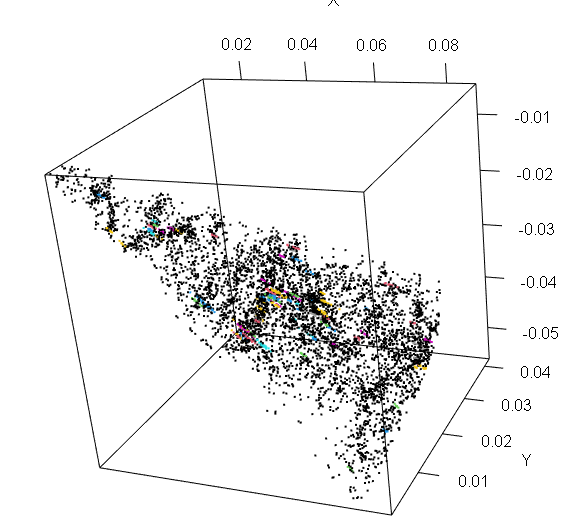

```r
aa <- sqldf("select
          GAL_ID,
          x,
          y,
          z,
            case
              when group_id IN (Select GROUP_ID from mm5) then group_id
          else 0
            end as group_id,
          redshift,
          dist
      from
            mm")

plot3d(aa$x, aa$y, aa$z, col = aa$group_id+1,
       size = 2, xlab = "X", ylab = "Y", zlab = "Z")
```

And the groups with more than min_members:

```r
plot3d(mm5$x, mm5$y, mm5$z, col = mm5$GROUP_ID,
       size = 2, xlab = "X", ylab = "Y", zlab = "Z")
```

# 5

[figure not shown]

# 6 Raw data processing

We will process the data without any kind of scale or normalization.

## 6.1 OPTICS

Optics clustering:

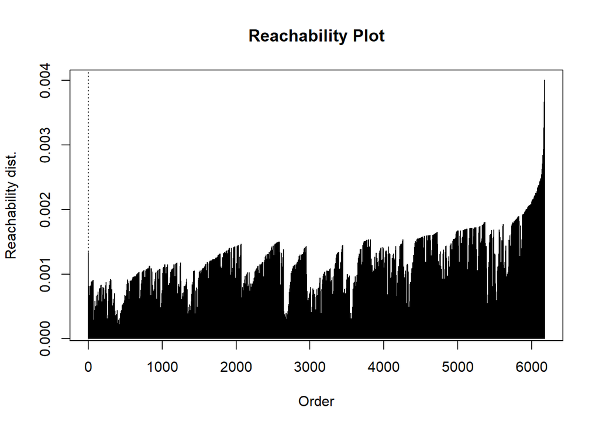

```r
points<- mm[,c('x', 'y', 'z')]

#clustering
res <- optics(points, minPts = min_members)
plot(res)
```

In the previous plot we can see how OPTICS modeling valleys (clusters) and the peaks (cluster-separation).

Execute extractXI to obtain a hierarchical clustering with $\xi=0.15$:

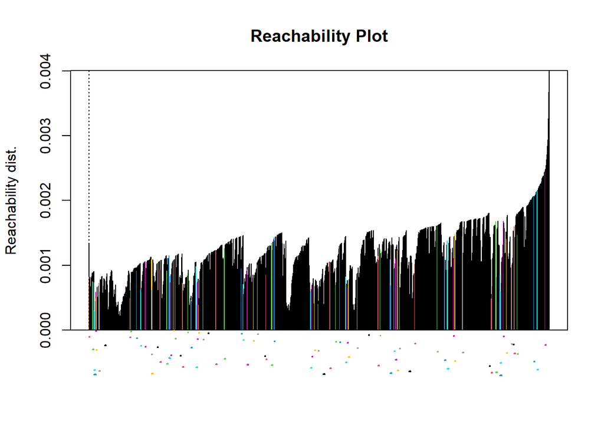

```r
optics <- extractXi(res, xi=0.15)
plot(optics)
```

### 6.1.1 Output-clusters visualization

Take a plot of the clustering obtained:

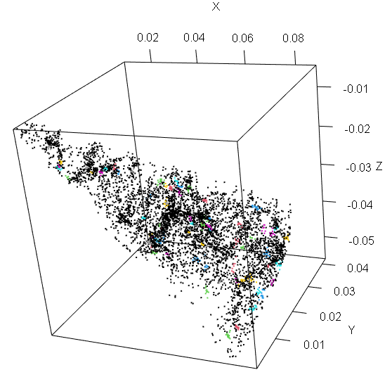

```r
plot3D_cluster(optics, mm)
```

As shown, this method do not work in clustering detection.

Stats with different values:

```r
mm$cluster_id <- as.numeric(optics$cluster)
mm5 <- get_elements_in_m5_groups(mm)
all <- execute_stats(mm, optics)
print_stats(all)
```

```
## [1] "Mean purity 0.843475697040166"
## [1] "Mean completness 0.335745304430738"
## [1] "Sum. recovery  0.15169194865811"
## [1] "Undetected groups 59 out of 92"
## [1] "Detected pure and complete groups 13  out of 92"
## [1] "Detected real groups  35  out of 92"
```

This algorithm do not offer good results in cluster detection and will not be used in this study.

## 6.2 DBSCAN

We can directly apply extractDBSCAN on the OPTICS model.

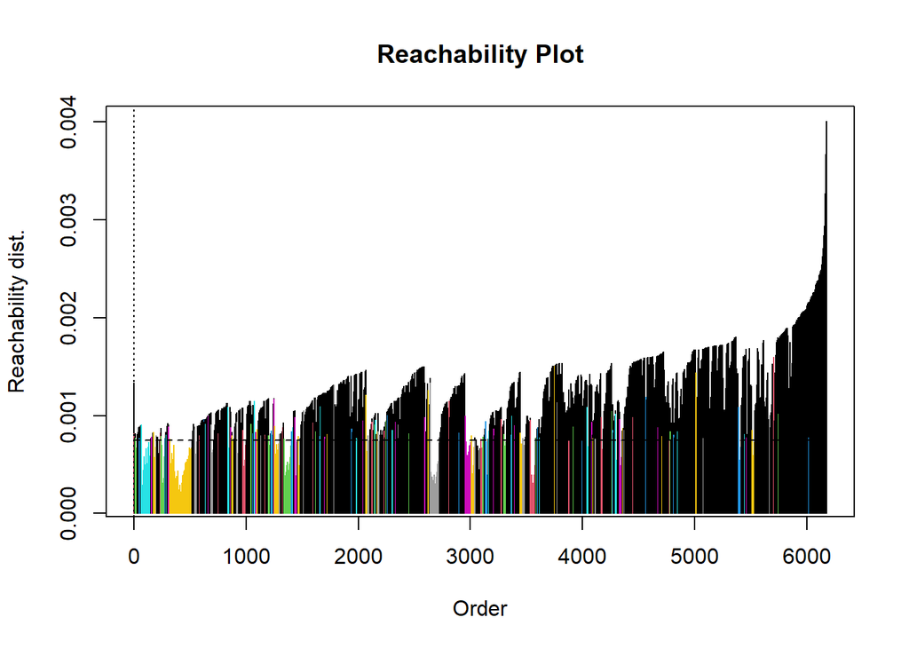

```r
blo_scan <- extractDBSCAN(res, eps_cl = 0.00075)
mm$cluster_id <- blo_scan$cluster
mm5 <- get_elements_in_m5_groups(mm)
plot(blo_scan)
```

### 6.2.1 Output-clusters visualization

We have, on one hand all groups with more than min_members members (made up by a reduced amount of galaxies from catalog)

in the other hand the output-clusters from DBSCAN:

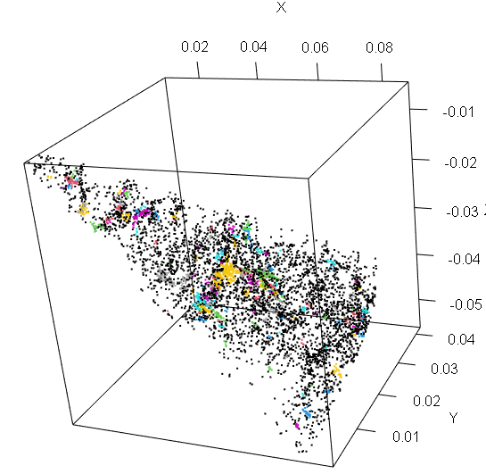

```r
plot3D_cluster(blo_scan, points)
```

```r
all <- execute_stats(mm, blo_scan)
head(all, 5)
```

```
##   cluster_id group_id total_in_group total_in_cluster total_in_cluster_group
## 1          3        0           5316               12                     12
## 2        119        0           5316               28                     28
## 3        114        0           5316               22                     16
## 4        165        0           5316               11                      7
## 5        145        0           5316                1                      1
##      purity     completn spurious bad_class is_pur is_comp recovery is_real
## 1 1.0000000 0.0022573363        0      5304      1       0        0       0
## 2 1.0000000 0.0052671181        0      5288      1       0        0       0
## 3 0.7272727 0.0030097818        6      5300      1       0        0       0
## 4 0.6363636 0.0013167795        4      5309      0       0        0       0
## 5 1.0000000 0.0001881114        0      5315      1       0        0       0
```

```r
print_stats(all)
```

```
## [1] "Mean purity 0.863902796650828"
## [1] "Mean completness 0.210196050618014"
## [1] "Sum. recovery  0.212368728121354"
## [1] "Undetected groups 53 out of 92"
## [1] "Detected pure and complete groups 13  out of 92"
## [1] "Detected real groups  40  out of 92"
```

We can now test over different values in order to obtain optimal eps_cl hyper-parameter:

```r
#It is easy to transform onto a function which admits a sequence and a res set.
eps_sequence_test <- seq(0.0002, 0.001, 0.0002)
x_stats <- extract_stats_dbscan(eps_sequence_test, res)
```

```
## [1] "Extracting DBSCAN stats for epsI=2e-04"
## [1] "Extracting DBSCAN stats for epsI=4e-04"
## [1] "Extracting DBSCAN stats for epsI=6e-04"
## [1] "Extracting DBSCAN stats for epsI=8e-04"
## [1] "Extracting DBSCAN stats for epsI=0.001"
```

Show the results obtained:

```r
print_global_stats(x_stats, eps_sequence_test)
```

```
## [1] "############### DATA FOR eps values ############"
## [1] "#############################################"
## [1] ""
## [1] ""
## [1] "Completeness 0.357292026300647 0.45088550911732 0.387454772536118 0.185205158447305 0.0625032612271289"
## [1] "Purity 0.841666666666667 0.822350354048467 0.832488216544073 0.878107873306566 0.92766517206685"
## [1] "Groups 11 57 59 36 13"
## [1] "Clusters 12 80 128 181 199"
## [1] "EPS 2e-04 4e-04 6e-04 8e-04 0.001"
## [1] "True Groups 92"
## [1] "Und. Groups 81 36 34 57 80"
## [1] "Complete gr.: 4 40 54 34 12"
## [1] "Pure gr.: 8 60 100 146 176"
## [1] "P.+ C. gr.: 3 31 36 13 4"
## [1] "Real groups: 12 63 60 36 12"
## [1] "Fr: 0.0326086956521739 0.33695652173913 0.391304347826087 0.141304347826087 0.0434782608695652"
## [1] "Fp: 0.615384615384615 0.740740740740741 0.775193798449612 0.802197802197802 0.88"
## [1] "FC: 0.307692307692308 0.493827160493827 0.418604651162791 0.186813186813187 0.06"
## [1] "Spurious: 1 2.3375 3.53125 3.86187845303867 4.08040201005025"
## [1] "Bad class: 12.5 1133.0125 2821.7890625 4251.59668508287 4982.40201005025"
## [1] "Recovery: 0.0280046674445741 0.339556592765461 0.345390898483081 0.136522753792299 0.0385064177362894"
```

Lets get a plots for completeness and purity:

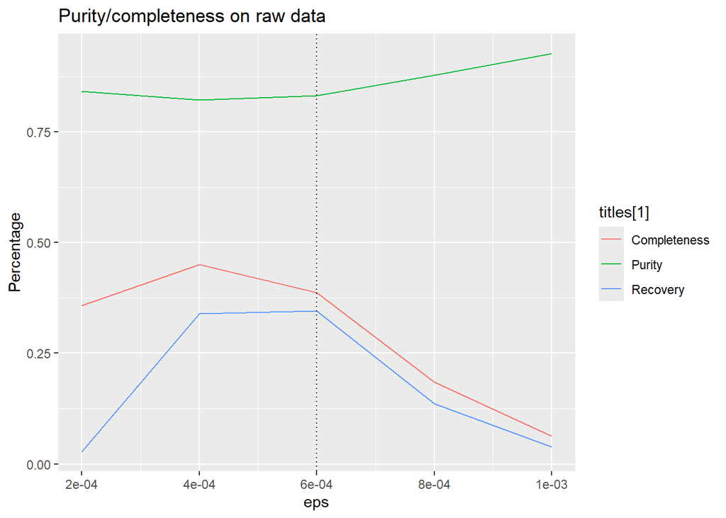

```r
seleced_eps <- 0.0006
plot_purity_completeness(
  eps_sequence_test,
  x_stats$purity_list,
  x_stats$completeness_list,
  x_stats$recovery,
  c('Purity', 'Completeness', 'Recovery'),
  "Purity/completeness on raw data",
  seleced_eps, 'eps', 'Percentage'
)
```

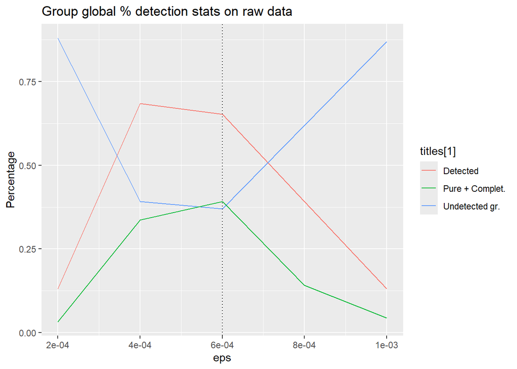

```r
plot_purity_completeness(
  eps_sequence_test,
  x_stats$real_list/true_groups,
  x_stats$und_gr/true_groups,
  x_stats$pure_complet/true_groups,
  c('Detected', 'Undetected gr.', 'Pure + Complet.'),
  "Group global % detection stats on raw data",
  seleced_eps , 'eps', 'Percentage'
)
```

For groups detection, we have:

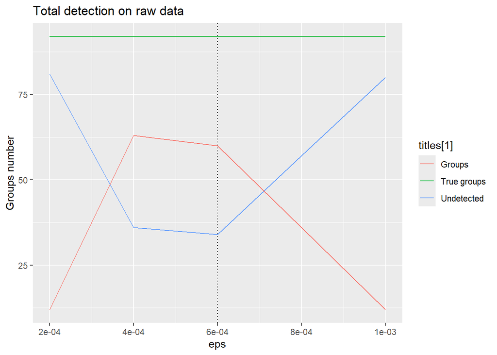

```r
plot_purity_completeness(
  eps_sequence_test,
  x_stats$und_gr,
  x_stats$real_list,
  true_groups - 0,
  c('Undetected', 'Groups', 'True groups'),
  "Total detection on raw data",
   seleced_eps , 'eps', 'Groups number'
)
```

# 7 HDBSCAN data processing

As said from theory, HDBSCAN does not generate a great model because it ability to detect clusters in sparse areas. It cause detect noise as clusters.

```r
cl <- hdbscan(points, minPts = 5)
length(unique( cl$cluster))
```

```
## [1] 278
```

## 7.1 Output-clusters visualization

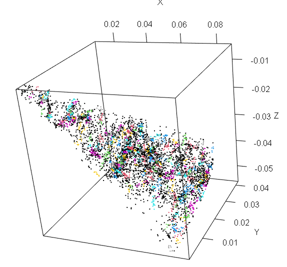

```r
plot3D_cluster(cl, mm)
```

HDBSCAN do not work pretty well because it detects cluster in sparser areas which gives as a result cluster detection on noise regions.

# 8 Density Peaks Clustering(DPC )

Alex Rodriguez and Alessandro Laio (2014).

https://github.com/thomasp85/densityClust

By making this way it appears some clusters:

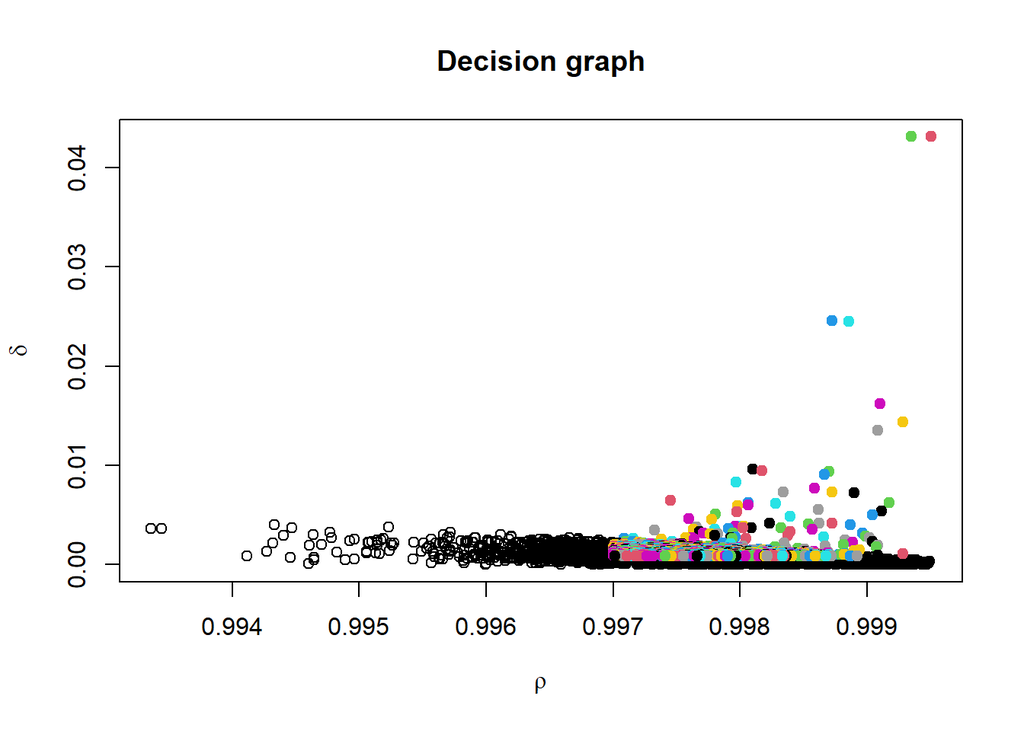

```r
points<- original_mm[,c('x', 'y', 'z')]
galaxyDens <- densityClust(points)
galaxyClusters <- findClusters(galaxyDens, rho=0.997, delta=0.00086)
plot(galaxyClusters)
```

```r
# do not use this takes a lot!!:
#plotMDS(galaxyClusters)

original_mm$cluster_id <- galaxyClusters$cluster
```

```r
all <- execute_stats(original_mm, galaxyClusters)
print_stats(all)
```

```
## [1] "Mean purity 0.709011309334738"
## [1] "Mean completness 0.984867626208164"
## [1] "Sum. recovery  1.41540256709452"
## [1] "Undetected groups 23 out of 92"
## [1] "Detected pure and complete groups 13  out of 92"
## [1] "Detected real groups  78  out of 92"
```

DPC is analogous to HDBCAN: the model do not fit well for the same reason: detecting clusters in noise regions.

May be DPC is not good in finding cluster but it can be useful in finding the centers by finding the peaks of density, as we show bellow:

```r
galaxyClusters <- findClusters(galaxyDens, rho=0.9985, delta=0.00084)
peaks <- original_mm[galaxyClusters$peaks,]
print(sprintf("DPC detected %s out of %s clusters", length(unique(peaks$GROUP_ID)), true_groups))
```

```
## [1] "DPC detected 87 out of 92 clusters"
```

In fact we can create a heat-map for $\rho$ and $\delta$ hyper-parameters:

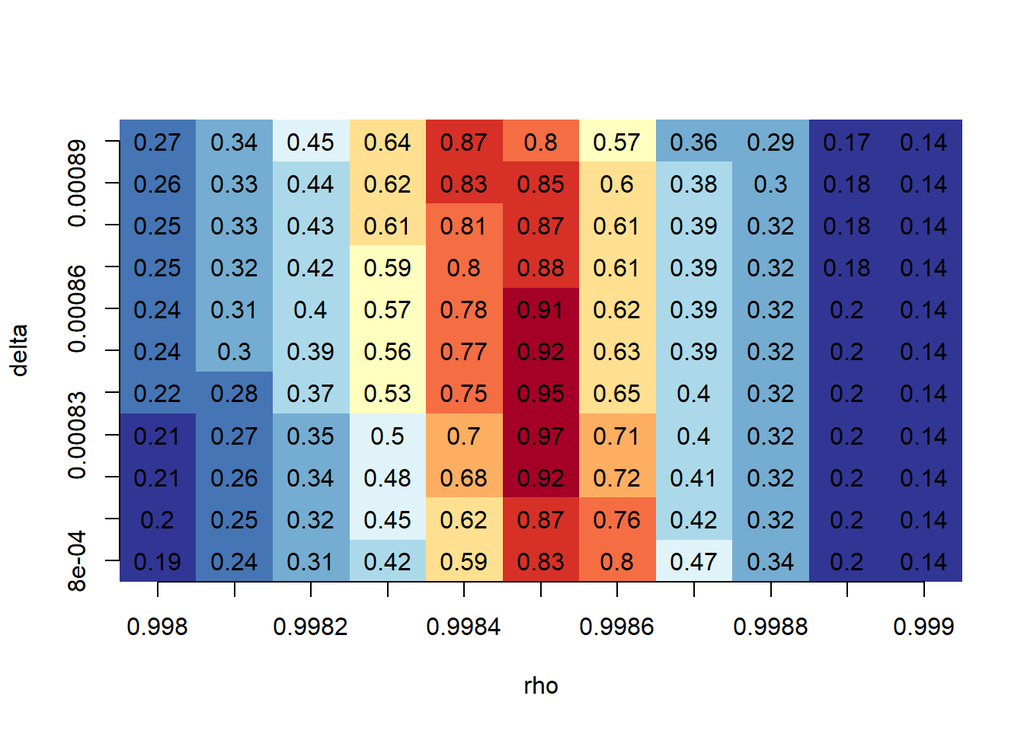

```r
rhos <- seq(0.9980, 0.999, 0.0001)
deltas <- seq(0.0008, 0.0009, 0.00001)

ll <-  length(deltas)
j<-1
i<-ll

matrix_data=matrix(ncol=length(rhos), nrow = length(deltas))
for (rho in rhos){
    for (delta in deltas){
        galaxyClusters <- findClusters(galaxyDens, rho=rho, delta=delta)
        peaks <- original_mm[galaxyClusters$peaks,]
        l <- length(unique(peaks$GROUP_ID))
        #print(min(l/true_groups, true_groups/l))
        matrix_data[i, j] <- min(l/true_groups, true_groups/l)
        #matrix_data[j, i] <- min(l/true_groups, true_groups/l)
        i <- i-1
    }
    j <- j+1
    i<-ll
}


custom_heatmap(matrix_data, deltas, rhos, xTitle = "rho", yTitle = "delta", numColors = 11)
```

In which case, we can see that $\delta=0.00083$ and $\rho=0.9985$ produce the best results with a 97% of group-centers detection.

## 8.1 Output-clusters visualization

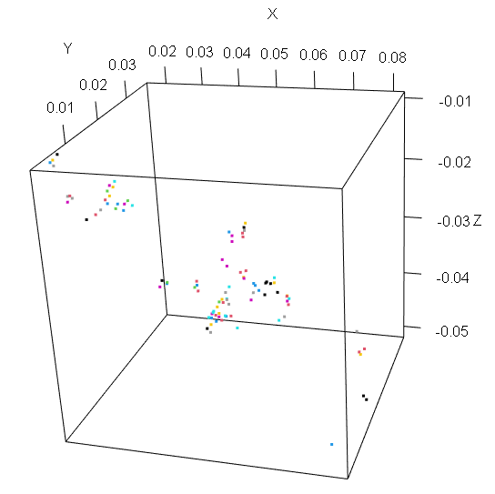

```r
galaxyClusters <- findClusters(galaxyDens, rho=0.9985, delta=0.00083)
peaks <- original_mm[galaxyClusters$peaks,]
plot3d(peaks$x, peaks$y, peaks$z, col = peaks$GROUP_ID+1,
         size = 3, xlab = "X", ylab = "Y", zlab = "Z")
```

And decision graph remains finally:

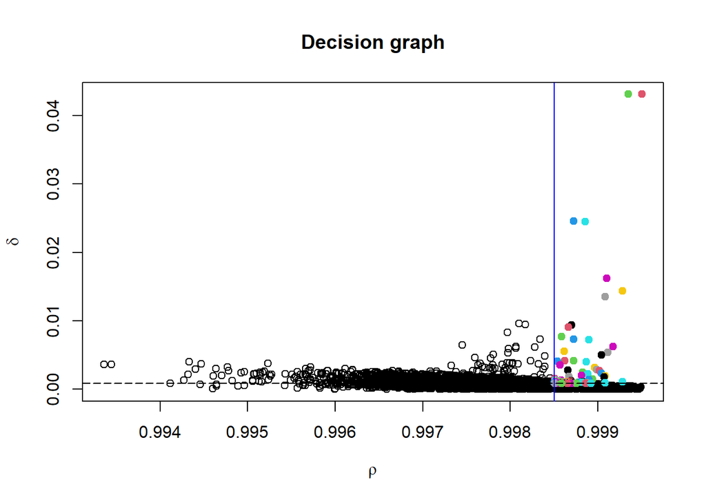

```r
plot(galaxyClusters)
abline(h =0.00084, lty = 5)
abline(v=0.9985, col="blue")
```

Note that DPC is good in obtaining groups centers but not in separate the groups over the global database as we can see

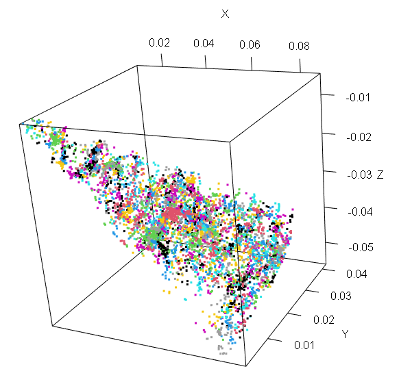

```r
plot3d(original_mm$x, original_mm$y, original_mm$z, col = original_mm$cluster_id+1,        size = 3, xlab = "X", ylab = "Y", zlab = "Z")
```

# 9 Normalized data processing

We will perform a scale of data:

```r
points<- mm[,c('x', 'y', 'z')]
points_scaled <- scale(points)
ress <- optics(points_scaled, minPts = min_members)
#optimal value obtained
blo_scans <- extractDBSCAN(ress, eps_cl = 0.025)
mm$cluster_id <- blo_scans$cluster
mm5 <- get_elements_in_m5_groups(mm)
```

Again we can do the same for scaled data:

```r
eps_sequence_test <- seq(0.035, 0.06, 0.005)
x_stats <- extract_stats_dbscan(eps_sequence_test, ress)
```

```
## [1] "Extracting DBSCAN stats for epsI=0.035"
## [1] "Extracting DBSCAN stats for epsI=0.04"
## [1] "Extracting DBSCAN stats for epsI=0.045"
## [1] "Extracting DBSCAN stats for epsI=0.05"
## [1] "Extracting DBSCAN stats for epsI=0.055"
## [1] "Extracting DBSCAN stats for epsI=0.06"
```

```r
print_global_stats(x_stats, eps_sequence_test)
```

```
## [1] "############### DATA FOR eps values ############"
## [1] "#############################################"
## [1] ""
## [1] ""
## [1] "Completeness 0.476065235887181 0.476920338017707 0.495861767267069 0.427936404199219 0.346002219941272 0.26100566374994"
## [1] "Purity 0.836425285499472 0.839912942500837 0.82521855781411 0.836773482617134 0.836745890340161 0.854918390394541"
## [1] "Groups 58 60 63 64 57 48"
## [1] "Clusters 84 94 105 130 148 168"
## [1] "EPS 0.035 0.04 0.045 0.05 0.055 0.06"
## [1] "True Groups 92"
## [1] "Und. Groups 35 33 30 29 36 45"
## [1] "Complete gr.: 45 49 58 59 53 46"
## [1] "Pure gr.: 67 73 80 100 108 128"
## [1] "P.+ C. gr.: 36 38 39 35 26 20"
## [1] "Real groups: 64 61 64 65 58 47"
## [1] "Fr: 0.391304347826087 0.41304347826087 0.423913043478261 0.380434782608696 0.282608695652174 0.217391304347826"
## [1] "Fp: 0.788235294117647 0.768421052631579 0.754716981132076 0.763358778625954 0.724832214765101 0.757396449704142"
## [1] "FC: 0.529411764705882 0.515789473684211 0.547169811320755 0.450381679389313 0.355704697986577 0.272189349112426"
## [1] "Spurious: 2.73809523809524 3.26595744680851 3.60952380952381 3.58461538461538 3.66891891891892 3.60714285714286"
## [1] "Bad class: 1267.66666666667 1865.67021276596 2074.32380952381 2655.78461538462 3228.78378378378 3823.38095238095"
## [1] "Recovery: 0.425904317386231 0.381563593932322 0.373395565927655 0.332555425904317 0.228704784130688 0.192532088681447"
```

The same plots before

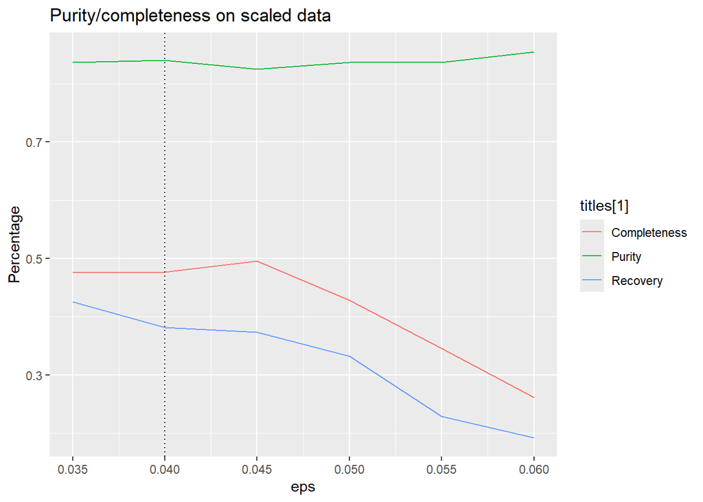

```r
seleced_eps <- 0.04
plot_purity_completeness(
  eps_sequence_test,
  x_stats$purity_list,
  x_stats$completeness_list,
  x_stats$recovery,
  c('Purity', 'Completeness', 'Recovery'),
  "Purity/completeness on scaled data",
  seleced_eps, 'eps', 'Percentage'
)
```

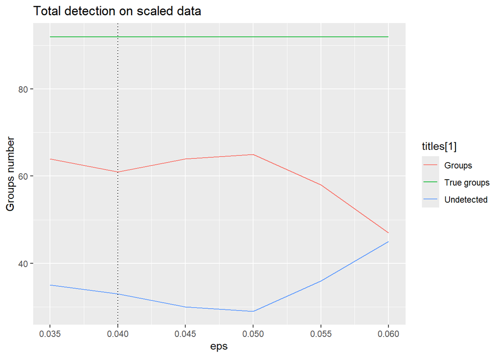

```r
plot_purity_completeness(
  eps_sequence_test,
  x_stats$und_gr,
  x_stats$real_list,
  true_groups - 0,
  c('Undetected', 'Groups', 'True groups'),
  "Total detection on scaled data",
   seleced_eps , 'eps', 'Groups number'
)
```

## 9.1 Elbow method

We have selected that minPts = min_members, which is a reasonable value for interpreting a group / clustering.

From the DBSCAN theory we can use the elbow on:

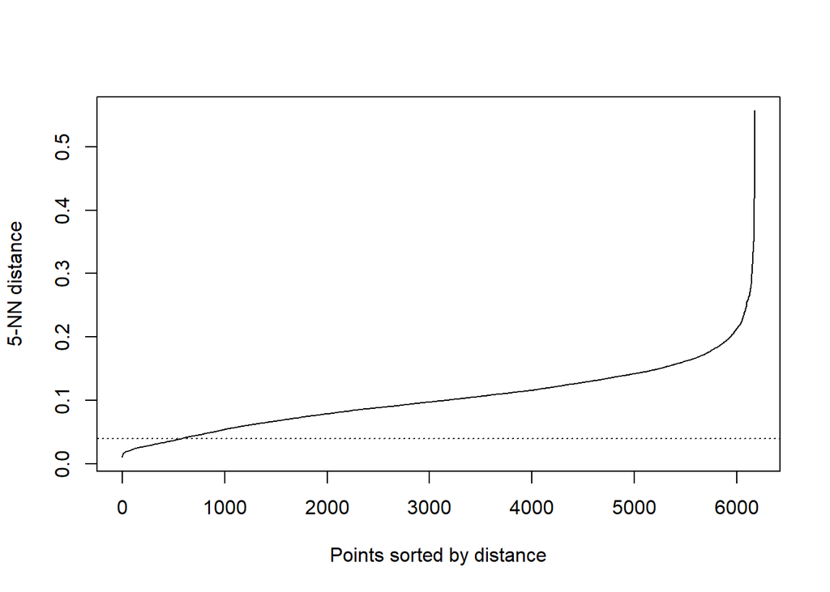

```r
kNNdistplot(x = points_scaled, k = min_members)
abline(h =seleced_eps, lty = 3)
```

How reader can see, the “elbow method” does not apply here, the reason for this is that elbow method try to optimize variances in clusters. Rather, we are trying to detect virialized galaxy groups, but algorithms are not intrinsically designed to account for the specific density profiles of dark matter halos.

## 9.2 Detected/Undetected original groups

The element whose groups were not detected are:

```r
blo_scans <- extractDBSCAN(ress, eps_cl = seleced_eps)
mm$cluster_id <- blo_scans$cluster

all <- execute_stats(mm, blo_scans)

undetected <- get_elements_not_in_groups(mm5, all)
detected <- get_elements_in_groups(mm, all)

print(sprintf('Undetected groups: %s', length(unique(undetected$GROUP_ID))))
```

```
## [1] "Undetected groups: 33"
```

```r
print(sprintf('Detected groups: %s', length(unique(detected$GROUP_ID))))
```

```
## [1] "Detected groups: 60"
```

Plot detected groups

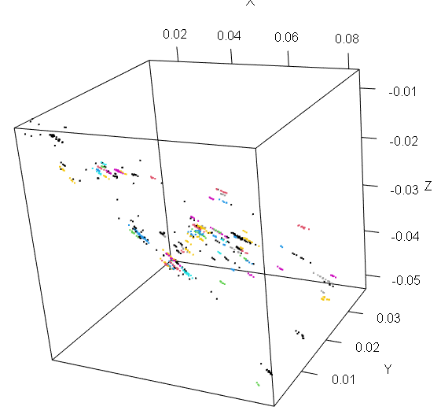

```r
plot3d(detected$x, detected$y, detected$z,
       col = detected$GROUP_ID +1, size = 2,
       xlab = "X", ylab = "Y", zlab = "Z")
```

Plot undetected groups

```r
plot3d(undetected$x, undetected$y, undetected$z,
       col = undetected$GROUP_ID, size = 2,
       xlab = "X", ylab = "Y", zlab = "Z")
```

# 10

[figure not shown]

# 11 s-Distances (SLos application)

We will use the code to calculate the s-distance, which consists in make a elongation along the line of sight.

## 11.1 sDistances Matrix Calculation

We can calculate distance matrix to apply OPTICS to this new metric, executing following code may take a long time:

```r
a<- mm[,c('x', 'y', 'z', 'dist', 'redshift')]
distance_matrix <- get_matrix_of_distances(a)
#Following code last a long time to execute
dist_object <- as.dist(distance_matrix)
```

## 11.2 OPTICS

Apply OPTICS algoritim and then obtain a reachability plot:

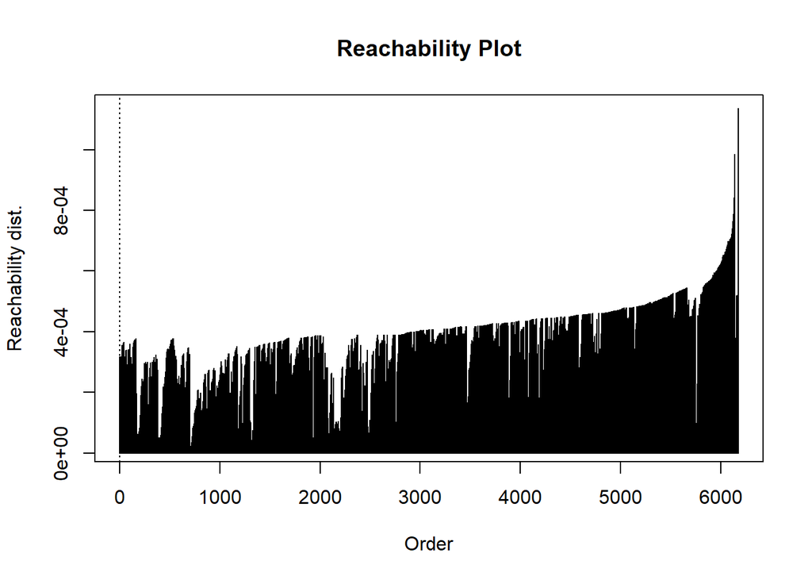

```r
sres <- optics(dist_object, minPts = min_members)
plot(sres)
```

## 11.3 DBSCAN:

Extract DBSCAN:

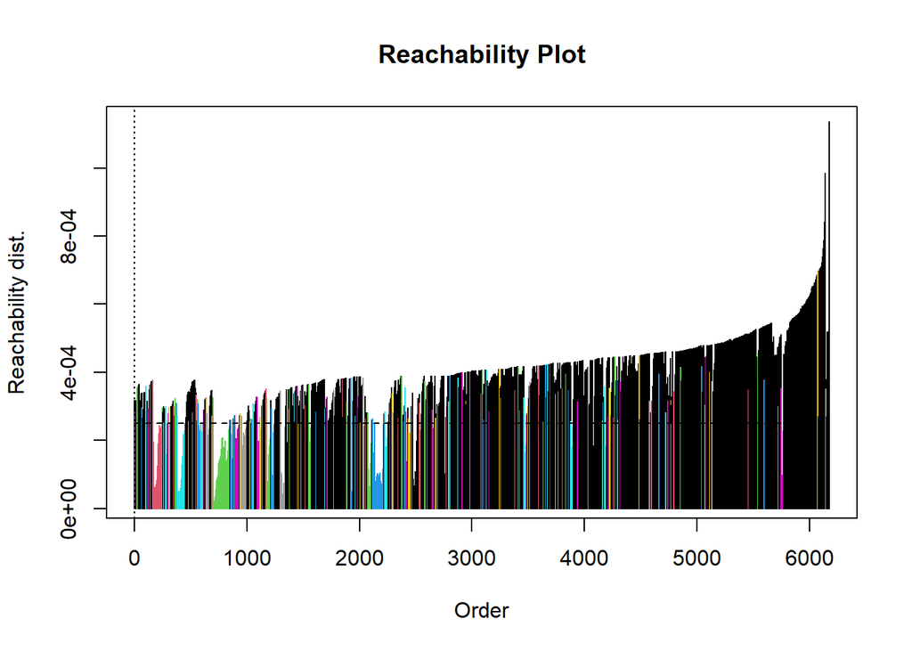

```r
sblo_scan <- extractDBSCAN(sres, eps_cl = 0.00025)
mm$cluster_id <- sblo_scan$cluster
#mm5 <- get_elements_in_groups(mm)
plot(sblo_scan)
```

```r
sall <- execute_stats(mm, sblo_scan)
print_stats(sall)
```

```
## [1] "Mean purity 0.884463005695639"
## [1] "Mean completness 0.321785953806393"
## [1] "Sum. recovery  0.345390898483081"
## [1] "Undetected groups 33 out of 92"
## [1] "Detected pure and complete groups 13  out of 92"
## [1] "Detected real groups  59  out of 92"
```

Test several hyper-parameters:

```r
#optimal value found at 0.00015
 eps_sequence_test <- seq(0.000075, 0.000120, 0.000005)
sx_stats <- extract_stats_dbscan(eps_sequence_test, sres)
```

```
## [1] "Extracting DBSCAN stats for epsI=7.5e-05"
## [1] "Extracting DBSCAN stats for epsI=8e-05"
## [1] "Extracting DBSCAN stats for epsI=8.5e-05"
## [1] "Extracting DBSCAN stats for epsI=9e-05"
## [1] "Extracting DBSCAN stats for epsI=9.5e-05"
## [1] "Extracting DBSCAN stats for epsI=1e-04"
## [1] "Extracting DBSCAN stats for epsI=0.000105"
## [1] "Extracting DBSCAN stats for epsI=0.00011"
## [1] "Extracting DBSCAN stats for epsI=0.000115"
## [1] "Extracting DBSCAN stats for epsI=0.00012"
```

```r
print_global_stats(sx_stats, eps_sequence_test)
```

```
## [1] "############### DATA FOR eps values ############"
## [1] "#############################################"
## [1] ""
## [1] ""
## [1] "Completeness 0.613737937981525 0.656296693210167 0.64498436107681 0.656888890469131 0.661426656619412 0.69268444439604 0.664641257674015 0.67637608773298 0.654330339280595 0.652192656682346"
## [1] "Purity 0.934988092111458 0.926057312785168 0.932433289830269 0.932661894615982 0.931384447681661 0.919803541110842 0.923462637645947 0.914728864640649 0.918566863956435 0.914497964007953"
## [1] "Groups 69 71 73 78 80 79 81 80 80 81"
## [1] "Clusters 80 81 87 94 100 98 106 105 111 114"
## [1] "EPS 7.5e-05 8e-05 8.5e-05 9e-05 9.5e-05 1e-04 0.000105 0.00011 0.000115 0.00012"
## [1] "True Groups 92"
## [1] "Und. Groups 24 22 20 15 13 14 12 13 13 12"
## [1] "Complete gr.: 59 63 65 73 75 75 78 77 77 79"
## [1] "Pure gr.: 76 76 83 90 95 93 101 98 104 106"
## [1] "P.+ C. gr.: 56 59 63 71 73 72 74 71 71 72"
## [1] "Real groups: 71 72 74 79 84 80 81 80 80 81"
## [1] "Fr: 0.608695652173913 0.641304347826087 0.684782608695652 0.771739130434783 0.793478260869565 0.782608695652174 0.804347826086957 0.771739130434783 0.771739130434783 0.782608695652174"
## [1] "Fp: 0.938271604938272 0.926829268292683 0.943181818181818 0.947368421052632 0.940594059405941 0.939393939393939 0.94392523364486 0.924528301886792 0.928571428571429 0.921739130434783"
## [1] "FC: 0.728395061728395 0.768292682926829 0.738636363636364 0.768421052631579 0.742574257425743 0.757575757575758 0.728971962616822 0.726415094339623 0.6875 0.68695652173913"
## [1] "Spurious: 0.8625 1.04938271604938 1.04597701149425 1.03191489361702 1 1.19387755102041 1.35849056603774 1.68571428571429 1.63063063063063 1.64912280701754"
## [1] "Bad class: 600.7875 592.79012345679 795.885057471264 849.542553191489 851.98 976.540816326531 1253.33962264151 1265.07619047619 1483.69369369369 1537.70175438596"
## [1] "Recovery: 0.663943990665111 0.698949824970828 0.738623103850642 0.791131855309218 0.813302217036173 0.806301050175029 0.80046674445741 0.754959159859977 0.754959159859977 0.775962660443407"
```

We get to the best value:

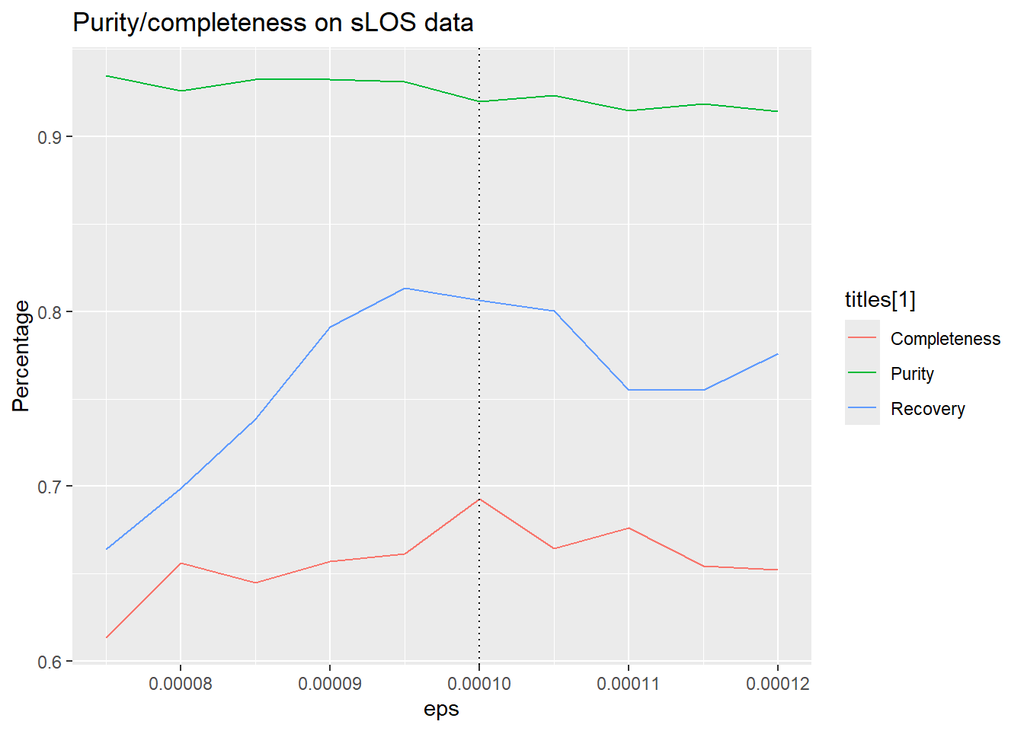

```r
seleced_eps <- 0.0001
plot_purity_completeness(
  eps_sequence_test,
  sx_stats$purity_list,
  sx_stats$completeness_list,
  sx_stats$recovery,
  c('Purity', 'Completeness', 'Recovery'),
  "Purity/completeness on sLOS data",
  seleced_eps, 'eps', 'Percentage'
)
```

There is a notable improvement of the results with the sLos distances.

Finally, for groups detection:

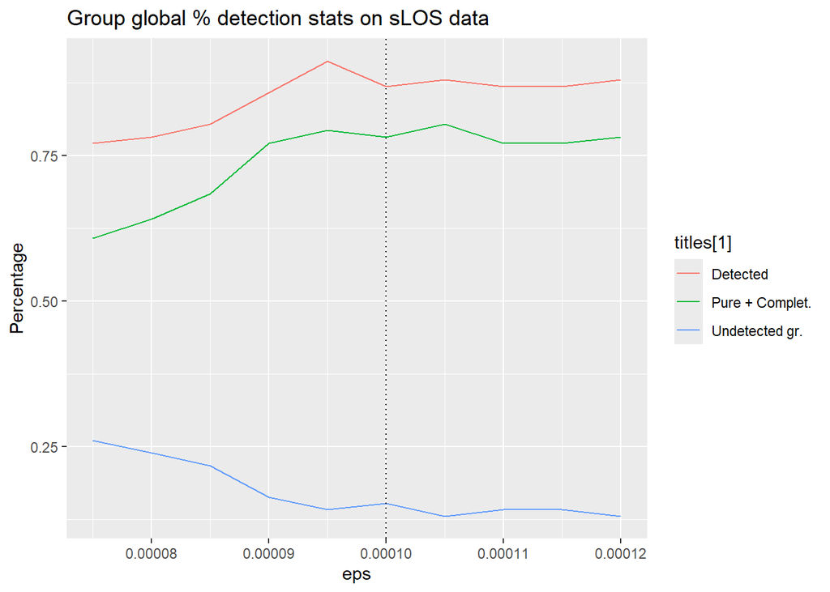

```r
plot_purity_completeness(
  eps_sequence_test,
  sx_stats$real_list/true_groups,
  sx_stats$und_gr/true_groups,
  sx_stats$pure_complet/true_groups,
  c('Detected', 'Undetected gr.', 'Pure + Complet.'),
  "Group global % detection stats on sLOS data",
  seleced_eps , 'eps', 'Percentage'
)
```

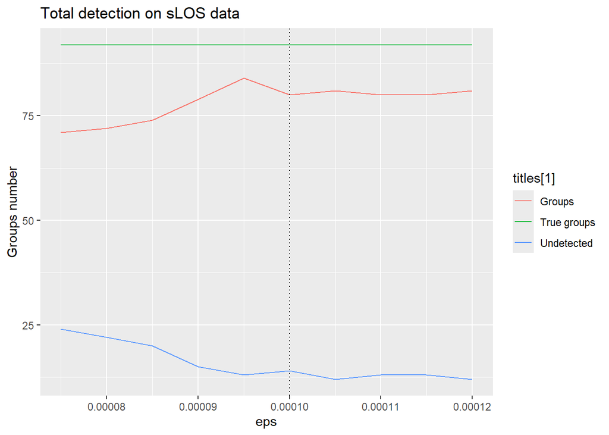

```r
plot_purity_completeness(
  eps_sequence_test,
  sx_stats$und_gr,
  sx_stats$real_list,
  true_groups - 0,
  c('Undetected', 'Groups', 'True groups'),
  "Total detection on sLOS data",
   seleced_eps , 'eps', 'Groups number'
)
```

Detected and undetected groups:

```r
sblo_scan <- extractDBSCAN(sres, eps_cl = seleced_eps)
mm$cluster_id <- sblo_scan$cluster

all <- execute_stats(mm, sblo_scan)

undetected <- get_elements_not_in_groups(mm5, all)
detected <- get_elements_in_groups(mm, all)

print(sprintf('Undetected groups: %s', length(unique(undetected$GROUP_ID))))
```

```
## [1] "Undetected groups: 14"
```

```r
print(sprintf('Detected groups: %s', length(unique(detected$GROUP_ID))))
```

```
## [1] "Detected groups: 79"
```

Plot detected groups:

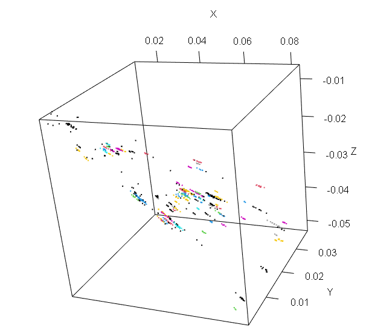

```r
plot3d(detected$x, detected$y, detected$z,
       col = detected$GROUP_ID +1, size = 2,
       xlab = "X", ylab = "Y", zlab = "Z")
```

Plot for not detected groups:

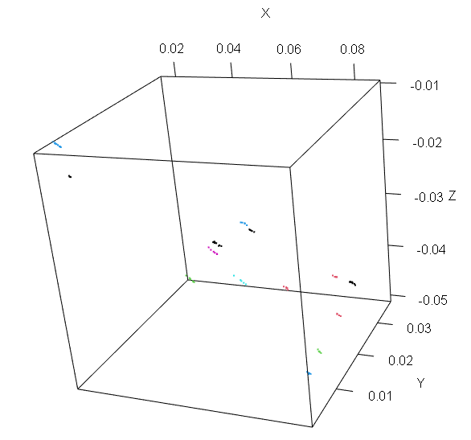

```r
plot3d(undetected$x, undetected$y, undetected$z,
       col = undetected$GROUP_ID +1, size = 2,
       xlab = "X", ylab = "Y", zlab = "Z")
```